# LDA

## Creando los topic models

Para crear los modelos, debemos usar el paquete `topicmodels` jutno al paquete de `tidytext` que veníamos usando.

Veamos cómo se hace.

La función LDA tiene 4 argumentos.

El primer argumento de LDA() es el data frame. Ahí especificamos la matriz que construímos recién. Luego se especifica el número de topics (clusters) que queremos. En este caso, 2. En tercer lugar, el método de estimación, para el cual usaremos Gibbs, que es, según la literatura, el más completo. Finalmente, se especifica el seed de la simulación, que debemos tratar como una lista.

```r
library(topicmodels)

lda_output <- LDA(
  dtm_review,
  k = 2,
  method = "Gibbs",
  control = list(seed = 42)
)
glimpse(lda_output)
```

```
## Formal class 'LDA_Gibbs' [package "topicmodels"] with 16 slots
##   ..@ seedwords      : NULL
##   ..@ z              : int [1:76175] 2 2 1 1 1 2 1 1 1 1 ...
##   ..@ alpha          : num 25
##   ..@ call           : language LDA(x = dtm_review, k = 2, method = "Gibbs", control = list(seed = 42))
##   ..@ Dim            : int [1:2] 1791 9670
##   ..@ control        :Formal class 'LDA_Gibbscontrol' [package "topicmodels"] with 14 slots
##   ..@ k              : int 2
##   ..@ terms          : chr [1:9670] "______________________________________________________________________first" "0_0" "0.3" "0.5" ...
##   ..@ documents      : chr [1:1791] "223" "615" "1069" "425" ...
##   ..@ beta           : num [1:2, 1:9670] -12.9 -10.4 -10.5 -12.8 -12.9 ...
##   ..@ gamma          : num [1:1791, 1:2] 0.399 0.437 0.475 0.476 0.364 ...
##   ..@ wordassignments:List of 5
##   .. ..$ i   : int [1:63116] 1 1 1 1 1 1 1 1 1 1 ...
##   .. ..$ j   : int [1:63116] 1 11 19 38 127 130 131 134 170 189 ...
##   .. ..$ v   : num [1:63116] 2 1 1 1 2 1 1 1 1 1 ...
##   .. ..$ nrow: int 1791
##   .. ..$ ncol: int 9670
##   .. ..- attr(*, "class")= chr "simple_triplet_matrix"
##   ..@ loglikelihood  : num -550450
##   ..@ iter           : int 2000
##   ..@ logLiks        : num(0)
##   ..@ n              : int 76175
```

Una vez creado el modelo, podemos extraer de él los tópicos. Esto se hace así.

```r
lda_topics <- lda_output %>%
  tidy(matrix = "beta") %>%
  arrange(desc(beta))
```

Podríamos evaluar hacer 3 topics en lugar de 2. Para ello, haríamos lo siguiente:

```r
lda_output2 <- LDA(
  dtm_review,
  k = 3,
  method = "Gibbs",
  control = list(seed = 42))

lda_topics2 <- lda_output2 %>%
  tidy(matrix = "beta") %>%
  arrange(desc(beta))
```

Y por supuesto podemos hacer para 4 topics también.

```r
lda_output3 <- LDA(
  dtm_review,
  k = 4,
  method = "Gibbs",
  control = list(seed = 42))

lda_topics3 <- lda_output3 %>%
  tidy(matrix = "beta") %>%
  arrange(desc(beta))
```

Con estas 3 matrices creadas, podemos hacer objetos que contengan las palabras con más probabilidad y luego graficar ese objeto usando ggplot para poder interpretar los tópicos.

Veamos primero los 2 tópicos originales.

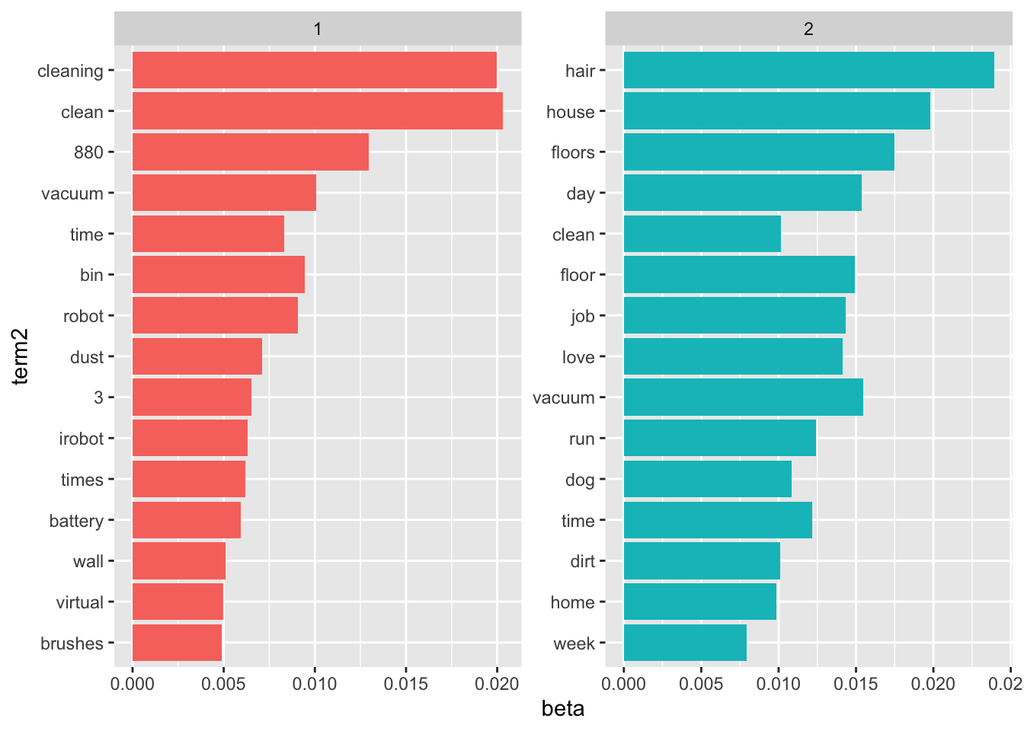

```r
word_probs <-lda_topics %>%
  group_by(topic) %>%
  top_n(15, beta) %>%
  ungroup() %>%
  mutate(term2 = fct_reorder(term,beta))

ggplot(word_probs, aes(x=term2, y=beta, fill = as.factor(topic))) +
  geom_col(show.legend = FALSE) +
  facet_wrap(~ topic, scales = "free") +
  coord_flip()
```

Ahora hagámoslo para los otros dos outputs, primero con K=3 y luego k=4.

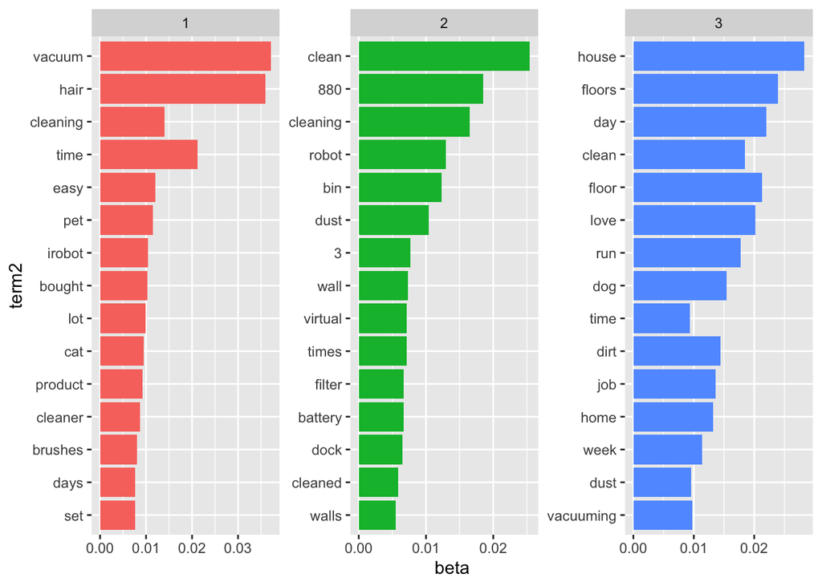

```r
word_probs2 <-lda_topics2 %>%
  group_by(topic) %>%
  top_n(15, beta) %>%
  ungroup() %>%
  mutate(term2 = fct_reorder(term,beta))

ggplot(word_probs2, aes(x=term2, y=beta, fill = as.factor(topic))) +
  geom_col(show.legend = FALSE) +
  facet_wrap(~ topic, scales = "free") +
  coord_flip()
```

Finalmente con 4 tópicos

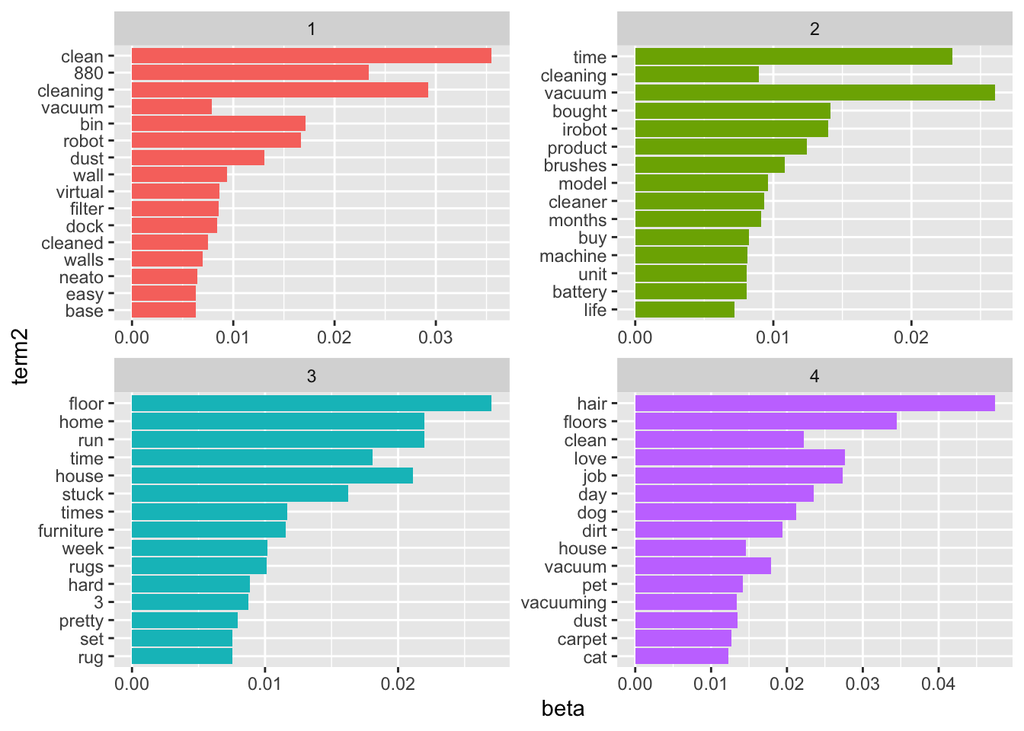

```r
word_probs3 <-lda_topics3 %>%
  group_by(topic) %>%
  top_n(15, beta) %>%
  ungroup() %>%
  mutate(term2 = fct_reorder(term,beta))

ggplot(word_probs3, aes(x=term2, y=beta, fill = as.factor(topic))) +
  geom_col(show.legend = FALSE) +
  facet_wrap(~ topic, scales = "free") +
  coord_flip()
```